# Homework 5 SDS315

Jade Lightfoot (jsl3652)

Github Repo: https://github.com/JadeLightfoot/Homework-5-SDS315

# **Problem 1- Iron Bank**

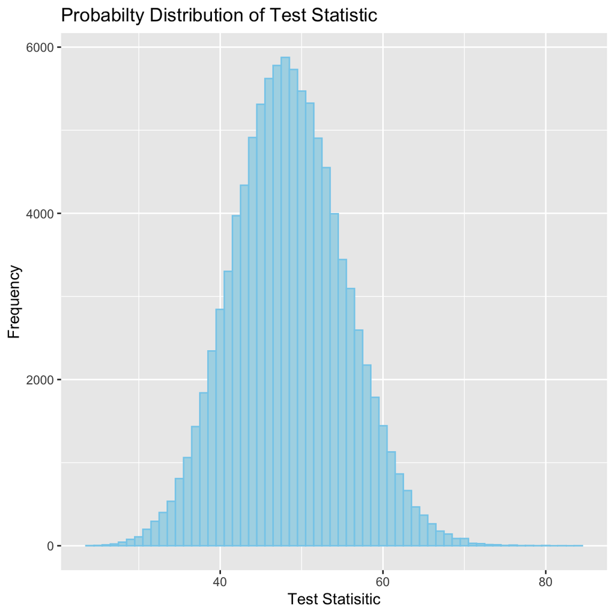

**NULL HYPOTHESIS**: Over the long run, securities trades from the Iron Bank are flagged at the same 2.4% baseline rate as that of other traders. We are testing if the observed data that states 70 flagged trades out of 2021 are consistent with the SEC’s null hypothesis.

**TEST STATISTIC**: The test statsitic used to measure evidence against the null hypothesis is 70

**P-VALUE**: The p-value is approximately 0.00189

# **Problem 2- Health Inspections**

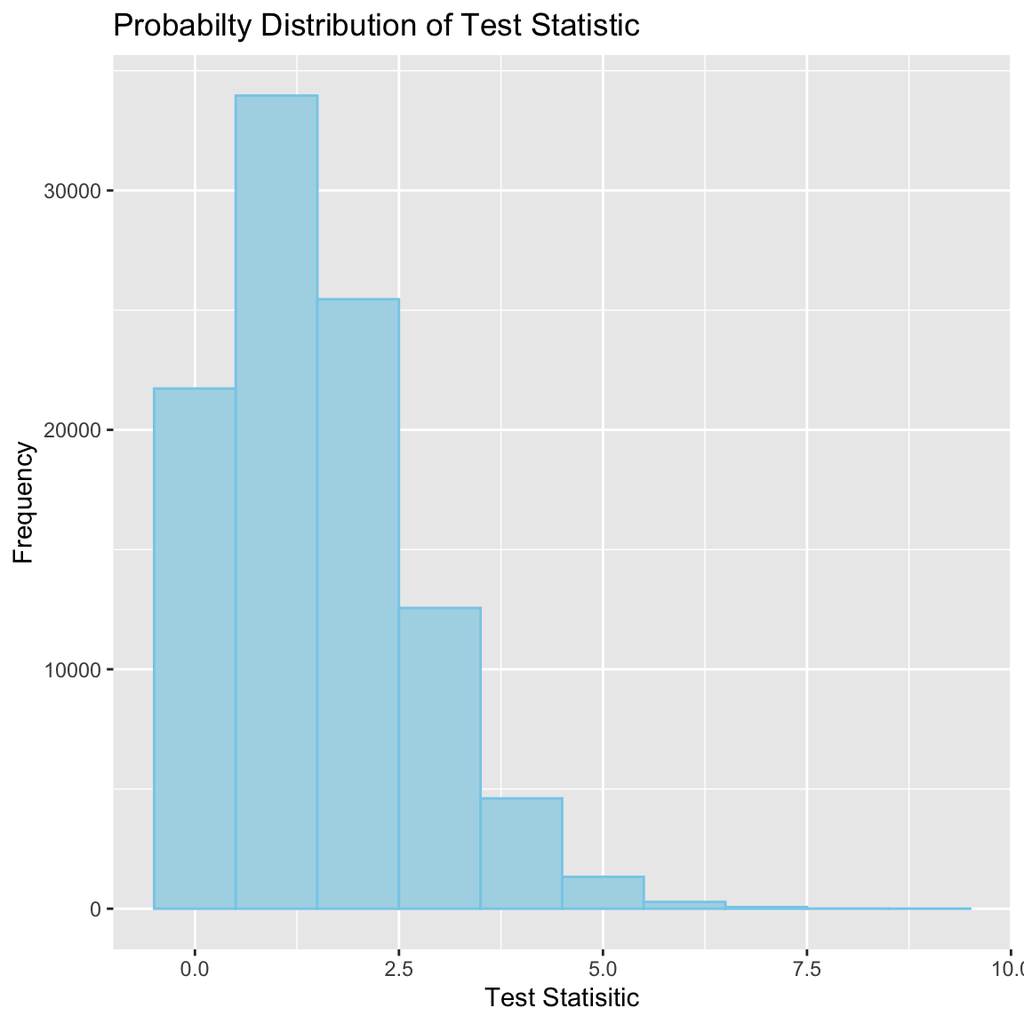

**NULL HYPOTHESIS**: The null hypothesis states that on average restrauants in the city are cited for health code violations at the same 3% baseline rate. We are testing if the observed data for 8 health code violations out of 50 remains the same. **TEST STATISTIC**: The test statistic used to measure evidence against the null hypothesis is 8.

**P-VALUE**: The p-value is approximately 0.00016

# **Problem 3- LLM watermarking**

### **PART A**:

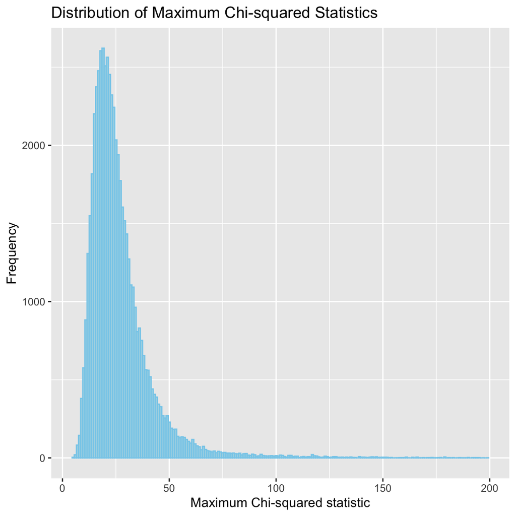

### **PART B**:

| Sentence | p_val |
| --- | --- |
| 1 | 0.5128 |
| 2 | 0.9263 |
| 3 | 0.0764 |
| 4 | 0.4891 |
| 5 | 0.4841 |
| 6 | 0.0088 |
| 7 | 0.3279 |
| 8 | 0.9880 |
| 9 | 0.0841 |
| 10 | 0.0590 |

The sentence with the lowest p-value is sentence number 6, “Feeling vexed after an arduous and zany day at work, she hoped for a peaceful and quiet evening at home, cozying up after a quick dinner with some TV, or maybe a book on her upcoming visit to Auckland.”.